# All Countries Environmental Data

## Method: PCA

Principal component analysis (PCA), part of descriptive analytics, is used to analyze one table of quantitative data, specifically useful for *high dimensional data* and comparitively lesser data rows. PCA mixes the input variables to give new variables, called principal components. The first principal component is the line of best fit. It is the line that maximizes the inertia (similar to variance) of the cloud of data points. Subsequent components are defined as orthogonal to previous components, and maximize the remaining inertia.

PCA gives one map for the rows (called factor scores), and one map for the columns (called loadings). These 2 maps are related, because they both are described by the same components. However, these 2 maps project different kinds of information onto the components, and so they are *interpreted differently*. Factor scores are the coordinates of the row observations and Loadings describe the column variables. Both can be interpreted through their distance from origin. However, Factor scores are also interpreted by the distances between them and Loadings interpreted by the angle between them.

The distance from the origin is important in both maps, because squared distance from the mean is inertia (variance, information; see sum of squares as in ANOVA/regression). Because of the Pythagorean Theorem, the total information contributed by a data point (its squared distance to the origin) is also equal to the sum of its squared factor scores.

With both Factor and Loadings maps combined we can interpret which grouping criteria of rows of data is most impacted by which columns. This can interpreted visually by observing which a factors and loadings on a particular component and the distance on this component.

PCA also helps in *dimensionality reduction*. Using SVD, we get eigen values arranged in descending order in the diagonal matrix. We can simply ignore the lower eigen values to reduce dimensions. We can also take help of SCREE plot to visually analyze importance of eigen values.

## Dataset

- Data: Measurements of environment conditions in Countries
- Rows: There are 137 observations, 1 for each country.
- Columns: Total 29 variables
- Qualitative: Country (nominal), Happiness (Ordinal).
- Quantitative: Aspect, Slope Crop Land, Tree Canopy Wind Cloud & Multiple variables for Temp & Rain
- Summary of Data

```r
str(country_env_df)
```

```
'data.frame':   137 obs. of  29 variables:
 $ Country                : Factor w/ 137 levels "Afghanistan",..: 1 2 3 4 5 6 7 8 9 10 ...
 $ Happiness_Rank         : Factor w/ 3 levels "VH","H","U": 3 2 2 3 1 3 1 1 2 3 ...
 $ accessibility_to_cities: num  317.7 73.8 1212.8 378.2 209.2 ...
 $ elevation              : num  1832 652 557 1061 683 ...
 $ aspect                 : num  201 192 185 174 145 ...
 $ slope                  : num  1.516 1.89 0.171 0.193 0.624 ...
 $ cropland_cover         : num  9.51 23.35 3.69 2.79 21.96 ...
 $ tree_canopy_cover      : num  0.375 12.805 0.177 19.87 8.834 ...
 $ isothermality          : num  35.9 33.2 40.3 64.3 49.9 ...
 $ rain_coldestQuart      : num  128.72 392.51 25.29 8.05 79.09 ...
 $ rain_driestMonth       : num  1.722 40.088 0.935 0.26 17.183 ...
 $ rain_driestQuart       : num  8.3 138.15 6.09 4.43 60.49 ...
 $ rain_mean_annual       : num  311.3 1151.1 79.5 1023.4 539.9 ...
 $ rain_seasonailty       : num  91.6 38.5 67.1 91.5 48.3 ...
 $ rain_warmestQuart      : num  12.69 138.33 9.51 318.54 183.14 ...
 $ rain_wettestMonth      : num  67.8 159 13.4 202.2 79.2 ...
 $ rain_wettestQuart      : num  175.8 435.9 33.3 524.3 211.7 ...
 $ temp_annual_range      : num  40.3 27.1 36.5 21.5 26.8 ...
 $ temp_coldestQuart      : num  -0.261 3.58 13.152 18.794 8.024 ...
 $ temp_diurnal_range     : num  14.72 9.11 14.87 13.85 13.46 ...
 $ temp_driestQuart       : num  21.1 19.6 26.9 18.9 11.1 ...
 $ temp_max_warmestMonth  : num  32 26.3 41.5 31 28.2 ...
 $ temp_mean_annual       : num  11.5 11.5 23 21.6 14.2 ...
 $ temp_min_coldestMonth  : num  -8.312 -0.806 5.058 9.549 1.443 ...
 $ temp_seasonality       : num  88.2 62.7 75.1 18.5 47.6 ...
 $ temp_warmestQuart      : num  22.7 19.6 32.5 23.3 20.2 ...
 $ temp_wettestQuart      : num  3.95 5.27 20.81 22.76 16.48 ...
 $ wind                   : num  3.43 2.47 4.03 2.16 4.27 ...
 $ cloudiness             : num  114.2 181.1 90.7 187.5 159 ...
```

- Research Question

How do the 137 countries differ on these variables?

|  | accessibility_to_cities | elevation | aspect | slope | cropland_cover | tree_canopy_cover | isothermality | rain_mean_annual | temp_mean_annual | wind | cloudiness |
| --- | --- | --- | --- | --- | --- | --- | --- | --- | --- | --- | --- |
| Afghanistan(U) | 317.71575 | 1831.7444 | 201.4298 | 1.5156001 | 9.511846 | 0.3746726 | 35.90442 | 311.32914 | 11.53331 | 3.432747 | 114.22898 |
| Albania(H) | 73.83086 | 651.8155 | 192.1303 | 1.8900753 | 23.346087 | 12.8046289 | 33.16941 | 1151.09747 | 11.46749 | 2.472694 | 181.13111 |
| Algeria(H) | 1212.79982 | 556.7583 | 184.9747 | 0.1708615 | 3.690864 | 0.1766562 | 40.29895 | 79.45607 | 22.96395 | 4.025770 | 90.67439 |
| Angola(U) | 378.20239 | 1061.4790 | 174.2569 | 0.1926286 | 2.794476 | 19.8701092 | 64.33239 | 1023.37470 | 21.61187 | 2.164405 | 187.51704 |
| Argentina(VH) | 209.21958 | 682.7993 | 145.0314 | 0.6238553 | 21.962504 | 8.8336096 | 49.85147 | 539.87247 | 14.20719 | 4.270904 | 159.00653 |
| Armenia(U) | 97.29452 | 1850.4830 | 183.5375 | 2.3188956 | 21.338266 | 6.9929146 | 32.42359 | 501.65877 | 6.16530 | 1.968253 | 191.76167 |

- PCA

```r
country_env_pca <- epPCA(DATA = country_env_df_for_pca, center = TRUE, scale = TRUE, DESIGN = country_env_df$Happiness_Rank, graphs = FALSE)
```

## Results

### Correlation Plot

Visually analyze multicollinearity in the system

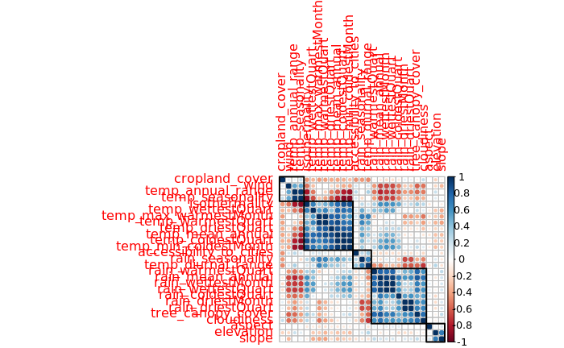

```r
corr_result = cor(country_env_df_for_pca)
corrplot(corr_result,order = 'hclust', addrect = 5)
```

### Scree Plot

Gives amount of information explained by corresponding component.

```r
country_env_scree <- plot(country_env_pca$ExPosition.Data$eigs, ylab = "Eigen values",
                       xlab = "Components",
                       type = "l",
                       main = "Scree Plot",)
points(country_env_pca$ExPosition.Data$eigs, cex = 2, pch = 19, col = "darkorchid4")
```

[figure not shown]

```r
points(country_env_pca$ExPosition.Data$eigs, cex = 2, pch = 21, col = "black")
```

## Summary

```r
country_factor_map <- PTCA4CATA::createFactorMap(country_env_pca$ExPosition.Data$fi, title='',
                                                 col.points = country_env_pca$Plotting.Data$fi.col,
                                                 col.labels = country_env_pca$Plotting.Data$fi.col,
                                                 display.labels = FALSE)

country_factor_map_mean <- PTCA4CATA::createFactorMap(country_env_pca_mean,
                                                 col.points = unique(country_env_pca$Plotting.Data$fi.col),
                                                 col.labels = unique(country_env_pca$Plotting.Data$fi.col),
                                                 display.labels = TRUE,
                                                 cex = 8,alpha.points = 0.8)

country_label4Map <- PTCA4CATA::createxyLabels.gen(1,2,lambda = country_env_pca$ExPosition.Data$eigs, tau = country_env_pca$ExPosition.Data$t)



country_map = country_factor_map$zeMap + country_label4Map + country_factor_map_mean$zeMap_dots + country_factor_map_mean$zeMap_text
print(country_map)

#country_map_mean = country_factor_map_mean$zeMap
#print(country_map_mean)
```

[output not shown]

```r
col_palate = brewer.pal(n = 12, name='Set3')

col4J = vector('list', nrow(country_env_pca$ExPosition.Data$fj))
col4J[grep('rain',rownames(country_env_pca$ExPosition.Data$fj))] = col_palate[1]
col4J[grep('temp',rownames(country_env_pca$ExPosition.Data$fj))] = 'red' #col_palate[2]
col4J[sapply(col4J, 'is.null')] = col_palate[3:11]

loadings_2 <- cor(country_env_df_for_pca, country_env_pca$ExPosition.Data$fi)

loadings_map <- PTCA4CATA::createFactorMap(loadings_2,
                        col.points = col4J,
                        col.labels = col4J,
                        constraints = list(minx = -1, miny = -1, maxx = 1 , maxy = 1))

corr_map <- loadings_map$zeMap_background  +  PTCA4CATA::addCircleOfCor() +
            loadings_map$zeMap_text +
            PTCA4CATA::addArrows(loadings_2, color = col4J)

print(corr_map)
```

[output not shown]

[figure not shown]

[figure not shown]